# ASHRAE - Great Energy Predictor III

Team 16: Koby Arndt, Casey Clark, Nick Ohlheiser, and Sean Powell

4/20/2021

## Introduction

For the ASHRAE - Great Energy Predictor Kaggle competition, we built a lightgbm model to predict the energy usage of different buildings given building and weather information. This markdown will go through the code to load in data, train the model, and make predictions.

In the first chunk, we will load in our necessary libraries and set a seed for consistent results. We will use data.table for efficient loading and transforming of large datasets. Fasttime is used for time parsing. Lightgbm contains the functions for training a light gradient boosting model. And lubridate is used for manipulating dates.

```r
library(data.table)
library(fasttime)
library(lightgbm)
library(lubridate)

set.seed(0)
```

## Data prep function

This prep function will be used to load, merge, and prepare our training data. fread from data.table is used to quickly read in large csv files. Kaggle provided three different datasets that needed to be merged into one training set, which is done on lines 43 and 44 within the function. We create several new columns, containing information from the datetime of the observation. These columns are weekday, hour, and season. Since we have several categorical variables, we convert the columns containing text to factors, then to integers. We change the factors to integers because lightgbm expects categorical variables to be integer encoded. Finally, the data is sorted by timestamp.

```r
#---------------------------
# create function for loading and prepping data
prep <- function(dt_fn, meta_fn, weather_fn, drops, sort_timestamp = FALSE, n_max = Inf){
  cat("Loading data...\n")
  dt <- fread(dt_fn, nrows = n_max, verbose = FALSE) # using fread to read train data
  weather <- fread(weather_fn, nrows = n_max, verbose = FALSE) # fread to read weather data
  meta <- fread(meta_fn, nrows = n_max, verbose = FALSE) # fread to read metadata

  cat("Merging datasets...\n")
  dt[meta, on = "building_id", names(meta) := mget(names(meta))] # add metadata to dt by 'building_id'
  dt[weather, on = c("site_id", "timestamp"), names(weather) := mget(names(weather))] # add weather data to dt by site id and timestamp

  # remove meta and weather data, since it was merged into dt
  rm(meta, weather)
  # call garbage collection to prompt R to return memory usage to operating system
  invisible(gc())

  cat("Processing features...\n")
  # drops are preselected columns that will be dropped from the model
  # note: changing columns to NULL values is preferred, as it takes 0 time and achieves the same result as deleting
  # fastPOSIXct easily converts string datetime into POSIXct objects
  # after it's converted, we create weekday and hour columns
  # create season column using lubridate's (quarter) starting at December
  # this splits the timestamps into 4 sections (Dec/Jan/Feb - Mar/Apr/May - Jun/Jul/Aug - Sep/Oct/Nov)
  # we also get the year built by subtracting 1900 in order to have two digit years
  # We take the log1p of square feet
  dt[, (drops) := NULL
     ][, timestamp := fastPOSIXct(timestamp)
       ][, `:=`(wday = wday(timestamp),
                hour = hour(timestamp),
                season = quarter(timestamp, with_year=FALSE, fiscal_start = 12),
                year_built = year_built - 1900,
                square_feet = log1p(square_feet))]

  cat("Converting categorical columns...\n")
  # if any subset of x's data is a character, convert to a factor, then to an integer.
  # lightgbm requires integer encoded categorical features, so R factors will not work
  dt[, names(dt) := lapply(.SD, function(x) {if (is.character(x)) x <- as.integer(as.factor(x)); x})]

  # sort the records by timestamp
  if (sort_timestamp) setorder(dt, timestamp)
  # remove timestamp column (remember we already split it into weekday, hour and year)
  dt[, timestamp := NULL]
}
```

## Data Preparation

Next, we specify our categorical variable columns and the columns we wish to drop from the model. After this, we run our prep function, providing our three datasets, the columns we wish to drop, and specify TRUE, which will tell the function to sort by timestamp. We then save our y variable as the log(1+x) of meter reading and remove this column from the train data. Lastly, we convert the train data.table to a data.matrix for lightgbm.

```r
#  cats will be used in lightgbm to specify categorical variables
cats <- c("meter", "primary_use", "hour", "wday", 'season')
# columns that will not be used in training
drops <- c("sea_level_pressure", "wind_direction", "wind_speed","building_id","site_id")
# run prep function on our train data files and save to tr
tr <- prep("train.csv",
           "building_metadata.csv",
           "weather_train.csv",
           drops, TRUE)
```

```
## Loading data...
## Merging datasets...
## Processing features...
## Converting categorical columns...
```

```r
# inspect data
str(tr)
```

```
## Classes 'data.table' and 'data.frame':   20216100 obs. of  13 variables:
##  $ meter            : int  0 0 0 0 0 0 0 0 0 0 ...
##  $ meter_reading    : num  0 0 0 0 0 0 0 0 0 0 ...
##  $ primary_use      : int  1 1 1 1 1 1 5 1 1 7 ...
##  $ square_feet      : num  8.91 7.91 8.59 10.07 11.67 ...
##  $ year_built       : num  108 104 91 102 75 100 81 89 103 110 ...
##  $ floor_count      : int  NA NA NA NA NA NA NA NA NA NA ...
##  $ air_temperature  : num  25 25 25 25 25 25 25 25 25 25 ...
##  $ cloud_coverage   : num  6 6 6 6 6 6 6 6 6 6 ...
##  $ dew_temperature  : num  20 20 20 20 20 20 20 20 20 20 ...
##  $ precip_depth_1_hr: num  NA NA NA NA NA NA NA NA NA NA ...
##  $ wday             : num  5 5 5 5 5 5 5 5 5 5 ...
##  $ hour             : int  19 19 19 19 19 19 19 19 19 19 ...
##  $ season           : int  1 1 1 1 1 1 1 1 1 1 ...
##  - attr(*, ".internal.selfref")=<externalptr>
```

```r
summary(tr)
```

```
##      meter        meter_reading       primary_use      square_feet
##  Min.   :0.0000   Min.   :       0   Min.   : 1.000   Min.   : 5.649
##  1st Qu.:0.0000   1st Qu.:      18   1st Qu.: 1.000   1st Qu.:10.390
##  Median :0.0000   Median :      79   Median : 2.000   Median :11.194
##  Mean   :0.6624   Mean   :    2117   Mean   : 4.158   Mean   :11.039
##  3rd Qu.:1.0000   3rd Qu.:     268   3rd Qu.: 7.000   3rd Qu.:11.843
##  Max.   :3.0000   Max.   :21904700   Max.   :16.000   Max.   :13.682
##
##    year_built        floor_count       air_temperature  cloud_coverage
##  Min.   :  0        Min.   : 1         Min.   :-28.90   Min.   :0
##  1st Qu.: 51        1st Qu.: 1         1st Qu.:  8.60   1st Qu.:0
##  Median : 69        Median : 3         Median : 16.70   Median :0
##  Mean   : 68        Mean   : 4         Mean   : 15.99   Mean   :2
##  3rd Qu.: 93        3rd Qu.: 6         3rd Qu.: 24.10   3rd Qu.:4
##  Max.   :117        Max.   :26         Max.   : 47.20   Max.   :9
##  NA's   :12127645   NA's   :16709167   NA's   :96658    NA's   :8825365
##  dew_temperature  precip_depth_1_hr      wday            hour
##  Min.   :-35.00   Min.   : -1       Min.   :1.000   Min.   : 0.0
##  1st Qu.:  0.00   1st Qu.:  0       1st Qu.:2.000   1st Qu.: 6.0
##  Median :  8.90   Median :  0       Median :4.000   Median :12.0
##  Mean   :  7.75   Mean   :  1       Mean   :4.013   Mean   :11.5
##  3rd Qu.: 16.10   3rd Qu.:  0       3rd Qu.:6.000   3rd Qu.:17.0
##  Max.   : 26.10   Max.   :343       Max.   :7.000   Max.   :23.0
##  NA's   :100140   NA's   :3749023
##      season
##  Min.   :1.000
##  1st Qu.:2.000
##  Median :3.000
##  Mean   :2.519
##  3rd Qu.:4.000
##  Max.   :4.000
##
```

```r
# take the log of meter reading and save as our y variable
y <- log1p(tr$meter_reading)
# remove meter reading from tr by making the column all NULL
tr[, meter_reading := NULL]
# convert tr to a data.matrix
tr <- data.matrix(tr)
```

## Model Training

In this section, we will define our lightgbm parameters and train our model. We will use ‘gbdt’ boosting for regression and will track rmse. Our training data will consist of 80% of the observations from the dataset and we will validate using the remaining 20%. To split the dataset, we use createDataPartition from the caret package to generate random indices.

For lightgbm, we prepare our train and validation datasets by subsetting our tr dataset using the indices from createDataPartition. This is also where we specify the integer encoded categorical variables. After this, we can train our lightgbm model using the predefined parameters, our 80% train data, 2000 rounds, our 20% validation daata, evaluation frequency of 200 and early stopping rounds of 200. After the model is trained, we can call the lgb.importance function to save and plot the importance of each feature.

In the importance graph below, we see that square footage is the most important feature, followed by meter type, year built, primary use, and air temperature. This means that our model gained the most information for predicting energy usage by the size of the building.

```r
# define lightgbm parameters
p <- list(boosting = "gbdt",
          objective = "regression_l2",
          metric = "rmse",
          nthread = 4,
          learning_rate = 0.05,
          num_leaves = 40,
          colsample_bytree = 0.85,
          lambda = 2)

N <- nrow(tr) # save the number of rows in tr
divideData<- caret::createDataPartition(y, p=0.8, list=FALSE) # 80% train, 20% validation
model<- list()
imp <- data.table()

# training once using 80% for train, 20% for val
xtrain<- lgb.Dataset(tr[divideData, ], label=y[divideData],categorical_feature = cats)
xval<- lgb.Dataset(tr[-divideData,], label=y[-divideData],categorical_feature = cats)
model[[1]]<- lgb.train(p, xtrain, 2000, list(val=xval), eval_freq=200, early_stopping_rounds = 200)
```

```
## [LightGBM] [Warning] Auto-choosing row-wise multi-threading, the overhead of testing was 0.815340 seconds.
## You can set `force_row_wise=true` to remove the overhead.
## And if memory is not enough, you can set `force_col_wise=true`.
## [LightGBM] [Info] Total Bins 993
## [LightGBM] [Info] Number of data points in the train set: 16172882, number of used features: 12
## [LightGBM] [Info] Start training from score 4.145755
## [1] "[1]:  val's rmse:2.12632"
## [1] "[201]:  val's rmse:1.38961"
## [1] "[401]:  val's rmse:1.28432"
## [1] "[601]:  val's rmse:1.21024"
## [1] "[801]:  val's rmse:1.16431"
## [1] "[1001]:  val's rmse:1.12805"
## [1] "[1201]:  val's rmse:1.09711"
## [1] "[1401]:  val's rmse:1.0741"
## [1] "[1601]:  val's rmse:1.0534"
## [1] "[1801]:  val's rmse:1.03615"
## [1] "[2000]:  val's rmse:1.02161"
```

```r
imp<- lgb.importance(model[[1]])
```

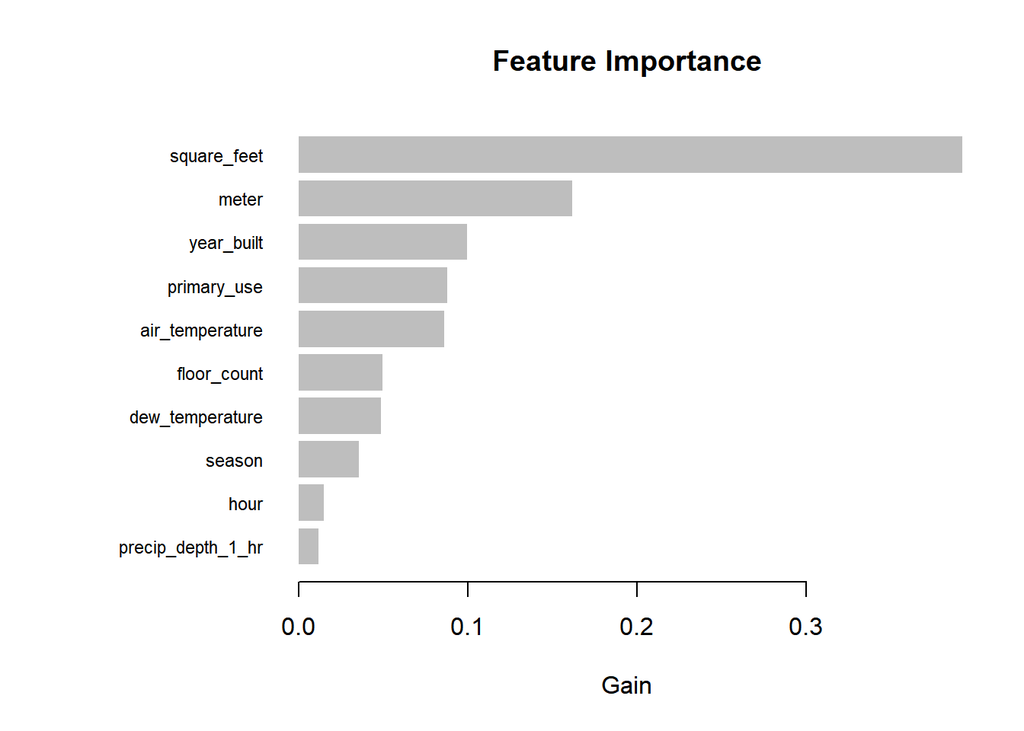

```r
rm(xtrain, xval)
invisible(gc())

# plot the importances from imp
lgb.plot.importance(imp)
```

```r
# remove these variables from the environment
rm(tr, y, imp, p, N, divideData)
invisible(gc())
```

## Load Test data to make predictions

```r
cat("Preparing test data...\n")
```

```
## Preparing test data...
```

```r
# use prep function on our test data, so we can make predictions
te <- prep("test.csv",
           "building_metadata.csv",
           "weather_test.csv",
           drops)
```

```
## Loading data...
## Merging datasets...
## Processing features...
## Converting categorical columns...
```

```r
invisible(gc())
str(te)
```

```
## Classes 'data.table' and 'data.frame':   41697600 obs. of  13 variables:
##  $ row_id           : int  0 1 2 3 4 5 6 7 8 9 ...
##  $ meter            : int  0 0 0 0 0 0 0 0 1 0 ...
##  $ primary_use      : int  1 1 1 1 1 1 5 1 1 1 ...
##  $ square_feet      : num  8.91 7.91 8.59 10.07 11.67 ...
##  $ year_built       : num  108 104 91 102 75 100 81 89 89 103 ...
##  $ floor_count      : int  NA NA NA NA NA NA NA NA NA NA ...
##  $ air_temperature  : num  17.8 17.8 17.8 17.8 17.8 17.8 17.8 17.8 17.8 17.8 ...
##  $ cloud_coverage   : num  4 4 4 4 4 4 4 4 4 4 ...
##  $ dew_temperature  : num  11.7 11.7 11.7 11.7 11.7 11.7 11.7 11.7 11.7 11.7 ...
##  $ precip_depth_1_hr: num  NA NA NA NA NA NA NA NA NA NA ...
##  $ wday             : num  7 7 7 7 7 7 7 7 7 7 ...
##  $ hour             : int  19 19 19 19 19 19 19 19 19 19 ...
##  $ season           : int  1 1 1 1 1 1 1 1 1 1 ...
##  - attr(*, ".internal.selfref")=<externalptr>
```

```r
te <- as.matrix(te[, row_id := NULL])
invisible(gc())
```

## Make Predictions

The last step in this competition is making predictions on the test set using our trained lightgbm model. Kaggle expects a specificly formatted csv for submission, so we also generate that in this last code chunk.

```r
pred_te <- sapply(model, function(m_lgb) expm1(predict(m_lgb, te)))
invisible(gc())

sub <- fread("sample_submission.csv")
sub[, meter_reading := round(rowMeans(pred_te), 2)
    ][meter_reading < 0, meter_reading := 0]
head(sub)
```

```
##    row_id meter_reading
## 1:      0          5.37
## 2:      1          4.75
## 3:      2          2.07
## 4:      3         10.75
## 5:      4         10.38
## 6:      5          2.52
```

```r
fwrite(sub, "submission2.csv")
```